{% raw %}

{% endraw %}

## Email network [email-Eu-core network](https://snap.stanford.edu/data/email-Eu-core.html)

The [email-Eu-core network](https://snap.stanford.edu/data/email-Eu-core.html) was generated from the email exchanges within a large European research institution. Each node represents an individual, and a directional edge from one individual to another represents some email exchanges between them in the specified direction. Each individual belongs to exactly one of 42 departments in the institution.

{% raw %}

`class` `EmailEuNetwork`[[source]](https://github.com/professorwug/directed_graphs/tree/master/directed_graphs/datasets.py#L14)

> `EmailEuNetwork`(**`transform`**=*`None`*, **`pre_transform`**=*`None`*) :: `InMemoryDataset`

" email-Eu-core network from Stanford Large Network Dataset Collection

The network was generated from the email exchanges within a large European research institution. Each node represents an individual, and a directional edge from one individual to another represents some email exchanges between them in the specified direction. Each individual belongs to exactly one of 42 departments in the institution.

{% endraw %} {% raw %}

{% endraw %}

Now it should be easy to download and extract the email network dataset.

{% raw %}

```python
from directed_graphs.datasets import EmailEuNetwork
dataset = EmailEuNetwork(transform=None, pre_transform=None)
data = dataset[0] # there is only graph in this dataset
```

```
Processing...
Done!
```

{% endraw %}

Let print out some information about this dataset.

{% raw %}

```
Number of nodes: 1005
Number of edges: 25571
Average node degree: 25.44
Is directed: True
Is coalesced: True
Has isolated nodes: True
Has self-loops: True
```

{% endraw %}

Let try to visualize this network using a simple heat map of the directed adjacency matrix. The nodes are ordered by the ground-truth communities. Intuitively, we would think that there would be more edges within a community than across communities. This phenomenon is definitely visible in the heatmap. In addition, although this directed adjacency matrix is definitely not symmetrical, the heat map does appear to be in some sense close to symmetrical.

{% raw %}

`visualize_heatmap`[[source]](https://github.com/professorwug/directed_graphs/tree/master/directed_graphs/datasets.py#L65)

> `visualize_heatmap`(**`edge_index`**, **`order_ind`**=*`None`*, **`cmap`**=*`'viridis'`*)

{% endraw %} {% raw %}

{% endraw %} {% raw %}

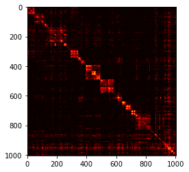

```python
order_ind = torch.argsort(data.y[:,1])
visualize_heatmap(data.edge_index, order_ind, cmap="hot")
```

{% endraw %}

## Add source and sink communities

In a directed graph, a node is a source if it has in-degree of 0, and a node is a sink if it has out-degree of 0. These notions can be generalized into source communities and sink communities (by communities we simply mean a group of nodes in the directed graph). If we think of information on the directed graph as some mass diffusing through random walk, then mass will stay in the sink communities once enter and mass will stay out of the source communities once exit. Then, the existence of source and/or sink communities could imbalancedly affect the measurement of diffusion curvature.

In order to assess and possibly correct this effect, we first want to create directed graphs with source and/or sink communities. We will do so by create pretransformation to existing directed graph data so to make all edges connected to some ground-truth communities pointing outwards (for source communities) or inwards (for sink communities).

We will be flexible and add a parameter `adv_prob` to indicate the probability of edges pointing in the *wrong* direction. This probability should be zero or close to zero.

There are two possible way to *correct* the edges that point in the wrong direction: either by reversing the direction or by removing the edge completely. The probability of employing these methods is specified by the probability `remove_prob`. This parameter could help mitigate the effect of excessive number of edges pointing out of (into resp.) source (sink resp.) communities.

{% raw %}

`class` `SourceSink`[[source]](https://github.com/professorwug/directed_graphs/tree/master/directed_graphs/datasets.py#L77)

> `SourceSink`(**`prob_source`**=*`0.1`*, **`prob_sink`**=*`0.1`*, **`adv_prob`**=*`0`*, **`remove_prob`**=*`0`*) :: `BaseTransform`

Transform a (directed or undirected) graph into a directed graph with a proportion of the nodes with mostly out-edges and a porportion of the nodes with mostly in-edges

Parameters

prob_source : float must be between 0 and 1 Proportion of nodes/communities to turn into source nodes/communities (with mostly out-edges) prob_sink : float must be between 0 and 1 prob_source and prob_sink must add up to no more than 1 Proportion of nodes/communities to turn into sink nodes/communities (with mostly in-edges) adv_prob : float must be between 0 and 1 Probability of in-edges for source nodes and/or out-edges for sink nodes remove_prob : float must be between 0 and 1 Probability of removing an in-edge for source nodes and/or out-edges for sink nodes 1 - remove_prob is the probability of reversing the direction of in-edge for source nodes and/or out-edges for sink nodes

{% endraw %} {% raw %}

{% endraw %}

Let try applying a transformation to the Email Network.

{% raw %}

```python
from directed_graphs.datasets import EmailEuNetwork, SourceSink
pre_transform = SourceSink(prob_source=0.3, prob_sink=0.2, adv_prob=0, remove_prob=0.1)
dataset = EmailEuNetwork(transform=None, pre_transform=pre_transform)
data = dataset[0]
```

{% endraw %}

{% raw %}

```
Number of nodes: 1005
Number of edges: 25058
Average node degree: 24.93
Is directed: True
Is coalesced: False
Has isolated nodes: True
Has self-loops: True
```

{% endraw %}

Let try visualize this new network, where the nodes are first ordered by ground-truth source/sink and then by ground-truth communities. The heat map now look much more clearly asymetrical, specifically with fewer edges in the lower triangular and more edges in the upper triangular. The transformation is supposed to turn the first 30% of the nodes into source communities and the last 20% of the nodes into sink communities. Indeed, there is no edges coming from the last 70% of the nodes into the first 30% of the nodes, and there is no edges coming from the last 20% of the nodes into the first 80% of the nodes.

{% raw %}

[figure not shown]

```python
import torch

order_ind = torch.argsort(data.y[:,1] + data.y[:,2]*data.num_nodes, descending=True)
visualize_heatmap(data.edge_index, order_ind)
```

{% endraw %}